# Loan Dataset Exploration

## Preliminary Wrangling

This data set contains 113,937 loans with 81 variables on each loan, including loan amount, borrower rate (or interest rate), current loan status, borrower income, and many others. Before starting the analysis the dataset, a wrangling process is done to prepare the dataset.

```python
# import all packages and set plots to be embedded inline
import numpy as np
import pandas as pd
import matplotlib.pyplot as plt
import seaborn as sb

%matplotlib inline
```

```python
df= pd.read_csv('loan_data.csv')
# Choosing 12 most important variables out of 81
col_list= ['ListingKey', 'Term', 'LoanStatus', 'BorrowerRate', 'ListingCategory (numeric)', 'EmploymentStatus', 'EmploymentStatusDuration', 'CreditScoreRangeLower', 'CreditScoreRangeUpper', 'IncomeRange', 'LoanOriginalAmount', 'DebtToIncomeRatio']
df= df[col_list]
df.head()
```

|  | ListingKey | Term | LoanStatus | BorrowerRate | ListingCategory (numeric) | EmploymentStatus | EmploymentStatusDuration | CreditScoreRangeLower | CreditScoreRangeUpper | IncomeRange | LoanOriginalAmount | DebtToIncomeRatio |
| --- | --- | --- | --- | --- | --- | --- | --- | --- | --- | --- | --- | --- |
| 0 | 1021339766868145413AB3B | 36 | Completed | 0.1580 | 0 | Self-employed | 2.0 | 640.0 | 659.0 | $25,000-49,999 | 9425 | 0.17 |
| 1 | 10273602499503308B223C1 | 36 | Current | 0.0920 | 2 | Employed | 44.0 | 680.0 | 699.0 | $50,000-74,999 | 10000 | 0.18 |
| 2 | 0EE9337825851032864889A | 36 | Completed | 0.2750 | 0 | Not available | NaN | 480.0 | 499.0 | Not displayed | 3001 | 0.06 |
| 3 | 0EF5356002482715299901A | 36 | Current | 0.0974 | 16 | Employed | 113.0 | 800.0 | 819.0 | $25,000-49,999 | 10000 | 0.15 |
| 4 | 0F023589499656230C5E3E2 | 36 | Current | 0.2085 | 2 | Employed | 44.0 | 680.0 | 699.0 | $100,000+ | 15000 | 0.26 |

```python
df.info()
```

```
<class 'pandas.core.frame.DataFrame'>
RangeIndex: 113937 entries, 0 to 113936
Data columns (total 12 columns):
ListingKey                   113937 non-null object
Term                         113937 non-null int64
LoanStatus                   113937 non-null object
BorrowerRate                 113937 non-null float64
ListingCategory (numeric)    113937 non-null int64
EmploymentStatus             111682 non-null object
EmploymentStatusDuration     106312 non-null float64
CreditScoreRangeLower        113346 non-null float64
CreditScoreRangeUpper        113346 non-null float64
IncomeRange                  113937 non-null object
LoanOriginalAmount           113937 non-null int64
DebtToIncomeRatio            105383 non-null float64
dtypes: float64(5), int64(3), object(4)
memory usage: 10.4+ MB
```

```python
df.isnull().sum()
```

```
ListingKey                      0
Term                            0
LoanStatus                      0
BorrowerRate                    0
ListingCategory (numeric)       0
EmploymentStatus             2255
EmploymentStatusDuration     7625
CreditScoreRangeLower         591
CreditScoreRangeUpper         591
IncomeRange                     0
LoanOriginalAmount              0
DebtToIncomeRatio            8554
dtype: int64
```

```python
df['EmploymentStatus'].value_counts()
```

```
Employed         67322
Full-time        26355
Self-employed     6134
Not available     5347
Other             3806
Part-time         1088
Not employed       835
Retired            795
Name: EmploymentStatus, dtype: int64
```

```python
df['IncomeRange'].value_counts()
```

```
$25,000-49,999    32192
$50,000-74,999    31050
$100,000+         17337
$75,000-99,999    16916
Not displayed      7741
$1-24,999          7274
Not employed        806
$0                  621
Name: IncomeRange, dtype: int64
```

## Data Assessment Summary

### Quality Issues

- A number of columns have missing values.
- The paranthesis in the name of ListingCategory column.
- ListingCategory values are numeric.
- CreditScoreRangeLower & Upper values are floats.
- EmploymentStatusDuration values are floats.
- EmploymentStatus has part-time, full-time and not employed types.
- 'Not Displayed' values in the IncomeRange column.
- IncomeRange column has 'Not employed' values.

```python
df_clean= df.copy()
```

## Data Cleaning

### Define

Remove null values of the following columns:

1. EmploymentStatus
2. EmploymentStatusDuration
3. CreditScoreRangeLower
4. CreditScoreRangeUpper
5. DebtToIncomeRatio

### Code

```python
col_null= ['EmploymentStatus', 'EmploymentStatusDuration', 'CreditScoreRangeLower', 'CreditScoreRangeUpper', 'DebtToIncomeRatio']
df_clean.dropna(axis= 0, inplace= True, subset= col_null)
```

### Test

```python
df_clean.isnull().sum()
```

```
ListingKey                   0
Term                         0
LoanStatus                   0
BorrowerRate                 0
ListingCategory (numeric)    0
EmploymentStatus             0
EmploymentStatusDuration     0
CreditScoreRangeLower        0
CreditScoreRangeUpper        0
IncomeRange                  0
LoanOriginalAmount           0
DebtToIncomeRatio            0
dtype: int64
```

### Define

Change the name of "ListingCategory (numeric)" column to "ListingCategory".

### Code

```python
df_clean= df_clean.rename(columns= {'ListingCategory (numeric)': 'ListingCategory'})
```

### Test

```python
df_clean.head()
```

|  | ListingKey | Term | LoanStatus | BorrowerRate | ListingCategory | EmploymentStatus | EmploymentStatusDuration | CreditScoreRangeLower | CreditScoreRangeUpper | IncomeRange | LoanOriginalAmount | DebtToIncomeRatio |
| --- | --- | --- | --- | --- | --- | --- | --- | --- | --- | --- | --- | --- |
| 0 | 1021339766868145413AB3B | 36 | Completed | 0.1580 | 0 | Self-employed | 2.0 | 640.0 | 659.0 | $25,000-49,999 | 9425 | 0.17 |
| 1 | 10273602499503308B223C1 | 36 | Current | 0.0920 | 2 | Employed | 44.0 | 680.0 | 699.0 | $50,000-74,999 | 10000 | 0.18 |
| 3 | 0EF5356002482715299901A | 36 | Current | 0.0974 | 16 | Employed | 113.0 | 800.0 | 819.0 | $25,000-49,999 | 10000 | 0.15 |
| 4 | 0F023589499656230C5E3E2 | 36 | Current | 0.2085 | 2 | Employed | 44.0 | 680.0 | 699.0 | $100,000+ | 15000 | 0.26 |
| 5 | 0F05359734824199381F61D | 60 | Current | 0.1314 | 1 | Employed | 82.0 | 740.0 | 759.0 | $100,000+ | 15000 | 0.36 |

### Code

```python
col_dtype= ['CreditScoreRangeLower', 'CreditScoreRangeUpper', 'EmploymentStatusDuration']
df_clean[col_dtype]= df_clean[col_dtype].astype(int)
```

### Test

```python
df_clean.info()
```

```
<class 'pandas.core.frame.DataFrame'>
Int64Index: 97888 entries, 0 to 113936
Data columns (total 12 columns):
ListingKey                  97888 non-null object
Term                        97888 non-null int64
LoanStatus                  97888 non-null object
BorrowerRate                97888 non-null float64
ListingCategory             97888 non-null int64
EmploymentStatus            97888 non-null object
EmploymentStatusDuration    97888 non-null int32
CreditScoreRangeLower       97888 non-null int32
CreditScoreRangeUpper       97888 non-null int32
IncomeRange                 97888 non-null object
LoanOriginalAmount          97888 non-null int64
DebtToIncomeRatio           97888 non-null float64
dtypes: float64(2), int32(3), int64(3), object(4)
memory usage: 8.6+ MB
```

### Define

Changing Full-time and Part-time values in the EmploymentStatus column to Employed.

### Code

```python
df_clean['EmploymentStatus']= df_clean['EmploymentStatus'].replace({"Full-time" : "Employed",
                                                                    "Part-time" : "Employed"})
```

### Test

```python
df_clean.EmploymentStatus.value_counts()
```

```
Employed         92445
Other             3520
Self-employed     1092
Retired            735
Not employed        96
Name: EmploymentStatus, dtype: int64
```

### Define

Assigning categories to the ListingCategory column.

### Code

```python
# Using data dictionary to interpret each number in the listingcategory column
cat_dic= {0 : 'Not_Available',
          1 : 'Debt_consolidation',
          2 : 'Home_improvement',
          3 : 'Business',
          4 : 'Personal_loan',
          5 : 'Student_use',
          6 : 'Auto',
          7 : 'Other',
          8 : 'Baby_and_adoption',
          9 : 'Boat',
          10 : 'Cosmetic_procedure',
          11 : 'Engagement_ring',
          12 : 'Green_loans',
          13 : 'Household_expenses',
          14 : 'Large_purchases',
          15 : 'Medical_Dental',
          16 : 'Motorcycle',
          17 : 'RV',
          18 : 'Taxes',
          19 : 'Vacation',
          20 : 'Wedding_loans'}

df_clean['ListingCategory'].replace(cat_dic, inplace= True)
```

### Test

```python
df_clean['ListingCategory'].value_counts()
```

```
Debt_consolidation    54617
Other                  9529
Not_Available          9161
Home_improvement       6958
Business               5204
Auto                   2363
Personal_loan          2271
Household_expenses     1787
Medical_Dental         1404
Large_purchases         806
Taxes                   788
Wedding_loans           731
Vacation                722
Student_use             605
Motorcycle              289
Engagement_ring         201
Baby_and_adoption       191
Boat                     83
Cosmetic_procedure       82
RV                       50
Green_loans              46
Name: ListingCategory, dtype: int64
```

### Define

Replace 'Not Displayed' values in the IncomeRange column with Nan and then drop them.

### Code

```python
df_clean['IncomeRange'].replace('Not displayed', np.nan, inplace= True)
df_clean.dropna(axis= 0, inplace= True)
```

### Test

```python
df_clean.isnull().sum()
```

```
ListingKey                  0
Term                        0
LoanStatus                  0
BorrowerRate                0
ListingCategory             0
EmploymentStatus            0
EmploymentStatusDuration    0
CreditScoreRangeLower       0
CreditScoreRangeUpper       0
IncomeRange                 0
LoanOriginalAmount          0
DebtToIncomeRatio           0
dtype: int64
```

### Define

Remove "Not employed" values in the IncomeRange column.

### Code

```python
df_clean= df_clean[df_clean['IncomeRange'] != "Not employed"]
```

### Test

```python
df_clean['IncomeRange'].value_counts()
```

```
$25,000-49,999    29875
$50,000-74,999    29354
$100,000+         16068
$75,000-99,999    16013
$1-24,999          6361
Name: IncomeRange, dtype: int64
```

```python
df_clean
```

|  | ListingKey | Term | LoanStatus | BorrowerRate | ListingCategory | EmploymentStatus | EmploymentStatusDuration | CreditScoreRangeLower | CreditScoreRangeUpper | IncomeRange | LoanOriginalAmount | DebtToIncomeRatio |
| --- | --- | --- | --- | --- | --- | --- | --- | --- | --- | --- | --- | --- |
| 0 | 1021339766868145413AB3B | 36 | Completed | 0.1580 | Not_Available | Self-employed | 2 | 640 | 659 | $25,000-49,999 | 9425 | 0.17 |
| 1 | 10273602499503308B223C1 | 36 | Current | 0.0920 | Home_improvement | Employed | 44 | 680 | 699 | $50,000-74,999 | 10000 | 0.18 |
| 3 | 0EF5356002482715299901A | 36 | Current | 0.0974 | Motorcycle | Employed | 113 | 800 | 819 | $25,000-49,999 | 10000 | 0.15 |
| 4 | 0F023589499656230C5E3E2 | 36 | Current | 0.2085 | Home_improvement | Employed | 44 | 680 | 699 | $100,000+ | 15000 | 0.26 |
| 5 | 0F05359734824199381F61D | 60 | Current | 0.1314 | Debt_consolidation | Employed | 82 | 740 | 759 | $100,000+ | 15000 | 0.36 |
| 6 | 0F0A3576754255009D63151 | 36 | Current | 0.2712 | Debt_consolidation | Employed | 172 | 680 | 699 | $25,000-49,999 | 3000 | 0.27 |
| 7 | 0F1035772717087366F9EA7 | 36 | Current | 0.2019 | Home_improvement | Employed | 103 | 700 | 719 | $25,000-49,999 | 10000 | 0.24 |
| 8 | 0F043596202561788EA13D5 | 36 | Current | 0.0629 | Other | Employed | 269 | 820 | 839 | $25,000-49,999 | 10000 | 0.25 |
| 9 | 0F043596202561788EA13D5 | 36 | Current | 0.0629 | Other | Employed | 269 | 820 | 839 | $25,000-49,999 | 10000 | 0.25 |
| 10 | 0F123545674891886D9F106 | 60 | Current | 0.2489 | Debt_consolidation | Employed | 300 | 640 | 659 | $75,000-99,999 | 13500 | 0.12 |
| 11 | 0F1734025150298088A5F2B | 36 | Completed | 0.1325 | Not_Available | Employed | 19 | 640 | 659 | $1-24,999 | 1000 | 0.27 |
| 12 | 0F1A3597143888805163EF7 | 36 | Past Due (1-15 days) | 0.1435 | Debt_consolidation | Employed | 1 | 680 | 699 | $25,000-49,999 | 4000 | 0.18 |
| 13 | 0F1C3583260311305D68F87 | 36 | Current | 0.1034 | Debt_consolidation | Employed | 98 | 740 | 759 | $50,000-74,999 | 8500 | 0.09 |
| 14 | 0F353575943675863D1AFC0 | 60 | Current | 0.0949 | Debt_consolidation | Employed | 35 | 740 | 759 | $100,000+ | 19330 | 0.20 |
| 15 | 0F483544120452347F48121 | 36 | Defaulted | 0.3177 | Household_expenses | Other | 121 | 700 | 719 | $50,000-74,999 | 4000 | 0.49 |
| 16 | 0F4835843081468212F0892 | 60 | Current | 0.2809 | Auto | Employed | 133 | 640 | 659 | $75,000-99,999 | 4000 | 0.15 |
| 18 | 0FF2357105361877390B58D | 36 | Current | 0.0974 | Debt_consolidation | Employed | 179 | 740 | 759 | $75,000-99,999 | 15000 | 0.24 |
| 19 | 0FFC35866018516621B0D3F | 60 | Current | 0.2225 | Debt_consolidation | Employed | 18 | 680 | 699 | $25,000-49,999 | 6500 | 0.41 |
| 20 | 101635959323992333B3C70 | 36 | Current | 0.1314 | Debt_consolidation | Employed | 175 | 660 | 679 | $50,000-74,999 | 14000 | 0.20 |
| 21 | 1017340630713945364DA6B | 36 | Completed | 0.2075 | Not_Available | Employed | 36 | 620 | 639 | $25,000-49,999 | 3000 | 0.09 |
| 22 | 101735700321773921526BF | 36 | Current | 0.3134 | Debt_consolidation | Other | 68 | 700 | 719 | $1-24,999 | 4000 | 9.20 |
| 23 | 101B35764008108187B2EBA | 36 | Defaulted | 0.2419 | Medical_Dental | Employed | 3 | 680 | 699 | $25,000-49,999 | 2000 | 0.39 |
| 24 | 101B3596709094692AC79C0 | 36 | Current | 0.1620 | Debt_consolidation | Employed | 91 | 660 | 679 | $25,000-49,999 | 4000 | 0.16 |
| 25 | 10223590888942486E3826E | 36 | Current | 0.2629 | Medical_Dental | Employed | 15 | 680 | 699 | $75,000-99,999 | 4000 | 0.12 |
| 26 | 0F4F3571508214190FD75CB | 60 | Completed | 0.2809 | Debt_consolidation | Employed | 25 | 660 | 679 | $25,000-49,999 | 4000 | 0.11 |
| 27 | 0F5034867864161084F3789 | 36 | Completed | 0.0920 | Debt_consolidation | Employed | 10 | 700 | 719 | $75,000-99,999 | 4000 | 0.26 |
| 28 | 0F53359346357513247D86B | 36 | Current | 0.1660 | Home_improvement | Employed | 48 | 720 | 739 | $25,000-49,999 | 10000 | 0.12 |
| 29 | 0F563597161095613517437 | 36 | Current | 0.1239 | Debt_consolidation | Employed | 16 | 740 | 759 | $100,000+ | 35000 | 0.32 |
| 30 | 0F57353904771934596FE9F | 36 | Completed | 0.0999 | Wedding_loans | Employed | 44 | 740 | 759 | $25,000-49,999 | 10000 | 0.11 |
| 31 | 0F683558129866945165D36 | 36 | Current | 0.3177 | Home_improvement | Other | 44 | 680 | 699 | $25,000-49,999 | 2000 | 0.04 |
| ... | ... | ... | ... | ... | ... | ... | ... | ... | ... | ... | ... | ... |
| 113901 | E6C0359472136859318BE87 | 60 | Current | 0.1274 | Debt_consolidation | Employed | 86 | 720 | 739 | $50,000-74,999 | 20000 | 0.30 |
| 113904 | C97434024964924789B94BC | 36 | Chargedoff | 0.2400 | Not_Available | Employed | 42 | 640 | 659 | $50,000-74,999 | 10000 | 0.55 |
| 113905 | C97E35311333117565C8E84 | 36 | Chargedoff | 0.3177 | Debt_consolidation | Employed | 175 | 740 | 759 | $25,000-49,999 | 4000 | 0.35 |
| 113906 | C982341623647969155E514 | 36 | Completed | 0.0680 | Business | Employed | 296 | 780 | 799 | $50,000-74,999 | 3001 | 0.12 |
| 113907 | C982359388882926442DE72 | 36 | Current | 0.3134 | Debt_consolidation | Employed | 86 | 640 | 659 | $25,000-49,999 | 4000 | 0.40 |
| 113909 | C98635564651525938EB38E | 60 | Current | 0.2498 | Home_improvement | Employed | 265 | 800 | 819 | $25,000-49,999 | 6000 | 0.24 |
| 113910 | C9873600264828351437CAB | 36 | Current | 0.2850 | Debt_consolidation | Employed | 8 | 640 | 659 | $100,000+ | 4000 | 0.18 |
| 113911 | C9883594035073098BC5D51 | 36 | Current | 0.2155 | Large_purchases | Employed | 51 | 660 | 679 | $25,000-49,999 | 10000 | 0.29 |
| 113912 | C98A3597264633447D66DF9 | 36 | Current | 0.0605 | Home_improvement | Employed | 102 | 800 | 819 | $25,000-49,999 | 4000 | 0.20 |
| 113913 | D2013482695428940FAD9E3 | 36 | Completed | 0.1030 | Debt_consolidation | Employed | 19 | 780 | 799 | $100,000+ | 8000 | 0.25 |
| 113915 | D2053427325575423785798 | 36 | Completed | 0.2000 | Other | Employed | 43 | 620 | 639 | $50,000-74,999 | 3000 | 0.26 |
| 113916 | D2063562664602024E13D82 | 36 | Current | 0.2932 | Household_expenses | Employed | 149 | 660 | 679 | $50,000-74,999 | 4000 | 0.15 |
| 113917 | D2063594229009539839457 | 36 | Current | 0.2850 | Debt_consolidation | Employed | 32 | 660 | 679 | $1-24,999 | 4000 | 0.40 |
| 113918 | D207342464194217591D1E1 | 36 | Defaulted | 0.1080 | Personal_loan | Employed | 252 | 740 | 759 | $50,000-74,999 | 7000 | 0.39 |
| 113919 | D20C3577637248543A1F80C | 36 | Current | 0.2346 | Home_improvement | Other | 12 | 680 | 699 | $25,000-49,999 | 4000 | 0.22 |
| 113920 | D20E358076984586576526D | 36 | Current | 0.3134 | Debt_consolidation | Employed | 110 | 740 | 759 | $50,000-74,999 | 4000 | 0.25 |
| 113922 | D2293427338962159DA5143 | 36 | Completed | 0.1295 | Student_use | Employed | 115 | 640 | 659 | $50,000-74,999 | 5000 | 0.18 |
| 113923 | E334343080922352965DF86 | 36 | Completed | 0.2089 | Debt_consolidation | Employed | 83 | 700 | 719 | $25,000-49,999 | 8000 | 0.57 |
| 113924 | E340356181565702714DBCE | 60 | Current | 0.1499 | Household_expenses | Employed | 56 | 640 | 659 | $25,000-49,999 | 5000 | 0.17 |
| 113925 | E3423576946812123E4798D | 36 | Current | 0.2712 | Debt_consolidation | Employed | 31 | 680 | 699 | $25,000-49,999 | 4000 | 0.28 |
| 113927 | E3433419834735803891976 | 36 | Completed | 0.0679 | Personal_loan | Employed | 69 | 760 | 779 | $100,000+ | 4292 | 0.06 |
| 113928 | E34935176664905343E01EA | 36 | Completed | 0.1899 | Business | Employed | 22 | 740 | 759 | $25,000-49,999 | 2000 | 0.27 |
| 113929 | E3553583161337791FCB87F | 36 | Completed | 0.2639 | Home_improvement | Employed | 25 | 660 | 679 | $50,000-74,999 | 2500 | 0.05 |
| 113930 | E35D3584034795373BCD69A | 36 | Current | 0.1639 | Debt_consolidation | Employed | 85 | 680 | 699 | $75,000-99,999 | 3000 | 0.20 |
| 113931 | E36F36005339663245C20F8 | 60 | Current | 0.1274 | Business | Employed | 12 | 800 | 819 | $75,000-99,999 | 25000 | 0.28 |
| 113932 | E6D9357655724827169606C | 36 | Current | 0.1864 | Debt_consolidation | Employed | 246 | 700 | 719 | $50,000-74,999 | 10000 | 0.13 |
| 113933 | E6DB353036033497292EE43 | 36 | FinalPaymentInProgress | 0.1110 | Other | Employed | 21 | 700 | 719 | $75,000-99,999 | 2000 | 0.11 |
| 113934 | E6E13596170052029692BB1 | 60 | Current | 0.2150 | Debt_consolidation | Employed | 84 | 700 | 719 | $25,000-49,999 | 10000 | 0.51 |
| 113935 | E6EB3531504622671970D9E | 60 | Completed | 0.2605 | Home_improvement | Employed | 94 | 680 | 699 | $25,000-49,999 | 15000 | 0.48 |
| 113936 | E6ED3600409833199F711B7 | 36 | Current | 0.1039 | Debt_consolidation | Employed | 244 | 680 | 699 | $50,000-74,999 | 2000 | 0.23 |

97671 rows × 12 columns

# Structure of the dataset

The original loan dataset contains 113,937 loans with 81 variables as columns. 12 columns out of 81 are selected to be analyzed in this study. The final loan dataset after completing the wrangling process consists of 97671 rows and 12 columns. It has various data types including integers, floats and strings.

### Main and supportive features of the dataset

The main features of interest in this dataset are the loan amounts and the interest rates. The supportive features in the dataset are employment status, income range, Loan term, credit score, employment duration and debt-to-income ratio.

## Univariate Exploration

In this section, the distribution of all individual variables are investigated for possible unusual points or outliers.

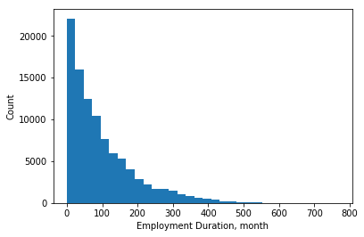

```python
bin_edges= np.arange(0, df_clean['EmploymentStatusDuration'].max()+24, 24)
plt.hist(data= df_clean, x= 'EmploymentStatusDuration', bins= bin_edges);
plt.xlabel('Employment Duration, month');
plt.ylabel('Count');
```

Q1. What is the distribution of employment duration? How many years of employment do the most borrower have?

Histogram should be used for employment duration since it is a numeric variable. The above histogram shows that the distribution of employment duration is highly skewed to the right. The majority of borrowers had been employed for less than 100 months (~ 8 years) at the time of listing.

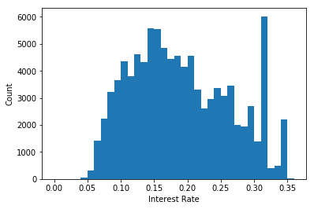

```python
bin_edges= np.arange(0, df_clean['BorrowerRate'].max()+0.01, 0.01)
plt.hist(data= df_clean, x= 'BorrowerRate', bins= bin_edges);
plt.xlabel('Interest Rate');
plt.ylabel('Count');
```

Q2. How is the distribution of interest rate and what are the lowest and highest rates?

Borrower's interest rate comment: BorrowerRate is also a numeric variable; therefore, histogram is the best choice to show its distribution. The lowest and highest interest rates in the dataset are 0.00 and 0.36 respectively. Below 0.3, the data is roughly unimodal with the greatest peak at around 0.15. However, the highest peak of the distribution occurred between 0.30 and 0.35 which corresponds to almost 6000 borrowers.

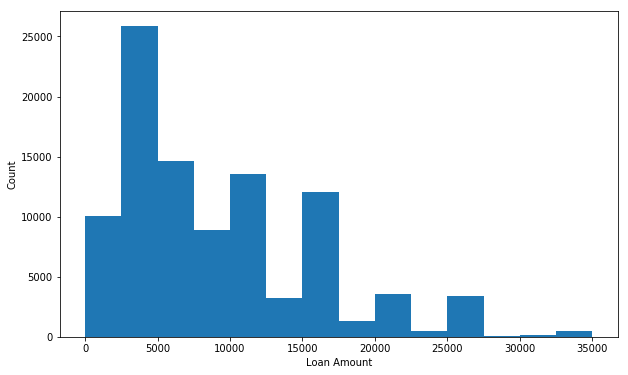

```python
plt.figure(figsize= [10,6])
bin_edges= np.arange(0, df_clean['LoanOriginalAmount'].max()+ 2500, 2500)
plt.hist(data= df_clean, x= 'LoanOriginalAmount', bins= bin_edges);
plt.xlabel('Loan Amount');
plt.ylabel('Count');
```

Q3. What is the highest count loan range offered to applicants?

LoanAmount comment: There is almost a downward trend in the number of borrowers as the loan amount increases. It can also be observed that the mode happened between \$2500 and \\$5000.

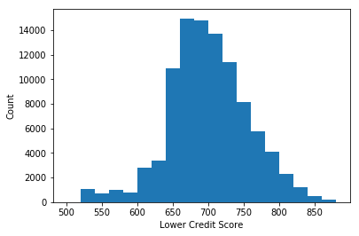

```python
bin_edges= np.arange(500, df_clean['CreditScoreRangeLower'].max()+ 20, 20)
plt.hist(data= df_clean, x= 'CreditScoreRangeLower', bins= bin_edges);
plt.xlabel('Lower Credit Score');
plt.ylabel('Count');
```

Q4. What is the distibution of lower credit score?

The length of each credit core range is 20. The distribution is unimodal and the mode of lower credit score in 660 which means that the mode of upper credit score is 679.

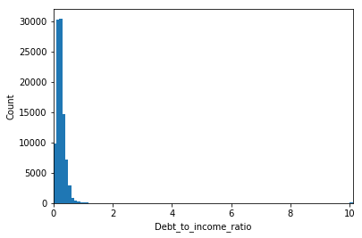

```python
bin_edges= np.arange(0, df_clean['DebtToIncomeRatio'].max()+ 0.1, 0.1)
plt.hist(data= df_clean, x= 'DebtToIncomeRatio', bins= bin_edges);
plt.xlabel('Debt_to_income_ratio');
plt.ylabel('Count');
plt.xlim(0,10.1);
```

Q5. Are there any unusual values in the dept-to-income-ratio variable?

The debt to income ratio for the majority of loan borrowers is less than 200% as depicted in the histogram. However, there exists some outliers which are far away from the other points having maximum of 1010%.

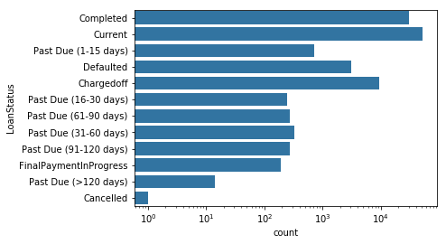

```python
base_color= sb.color_palette()[0]
sb.countplot(data= df_clean, y= 'LoanStatus', color= base_color);
plt.xscale('log')
```

Q6. What status has the highest count in the loan status variable?

LoanStatus is a categorical variable that can be well presented by a seaborn countplot. Current loans have the highest count followed by Completed and Chargedoff ones.

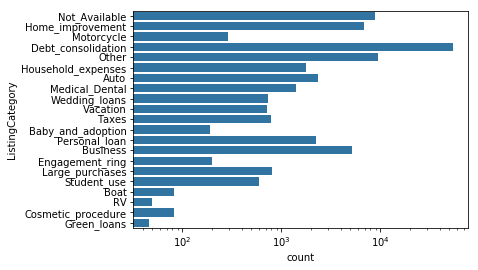

```python
sb.countplot(data= df_clean, y= 'ListingCategory', color= base_color);
plt.xscale('log')
```

Q7. What are the main purposes of borrowing a loan by applicants?

There are many variables so a horizontal bar chart is a suitable visualization. Interestingly, most loans were borrowed in order to consolidate applicants' other loans. Other reasons, home improvement and business are respectively among the top purposes of getting loans. This can be dangerous because many people will use it to pay off their credit cards and then run up even more debt within a few years.

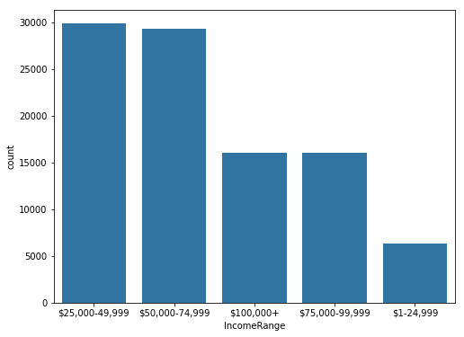

```python
plt.figure(figsize= [8,6])
sb.countplot(data= df_clean, x= 'IncomeRange', color= base_color);
```

Q8. How does the income range vary among the applicants in the dataset?

A bar chart is used to show the distribution of IncomeRange column since it is a categorical variable. The majority of applicants' salaries fall in the range of \$25,000 to \\$75,000. Borrowers with less than \$25,000 salary have the least count in the dataset.

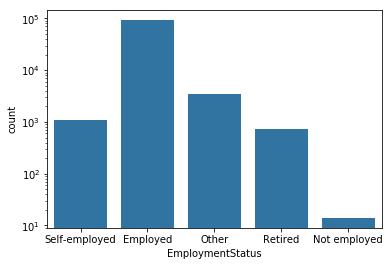

```python
sb.countplot(data= df_clean, x= 'EmploymentStatus', color= base_color);
plt.yscale('log')
```

Employed borrowers have the highest proportion followed by Other, self-employed and not employed.

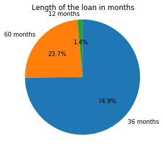

```python
sorted_counts= df_clean['Term'].value_counts()
plt.pie(sorted_counts, labels= ['36 months', '60 months', '12 months'], startangle= 90, counterclock= False, autopct='%1.1f%%');
plt.axis('square');
plt.title('Length of the loan in months');
```

Q9. What is the proportion of loan duration terms in the dataset?

A pie chart is used for the demonstration of the term of loans since there are only three types in this category. It can be observed that loans with the duration of 36 months are the most popular ones accounting for 74.9%. 60 months and 12 months loans comprised of 23.7% and 1.4% respectively.

### Discuss the distribution(s) of your variable(s) of interest. Were there any unusual points? Did you need to perform any transformations?

> The loan amount and borrower interest rate are my main variables of interest. The loan amount distribution is highly right skewed with the minimum of 1000 and maximum of 35000 dollars. The mode of the laon amounts is between 2500 and 5000 dollars. Borrower's interest rate is the other main variable with the lowest and highest values of 0.00 and 0.36 respectively. Below 0.3, the data is roughly unimodal with the greatest peak at around 0.15. However, the highest peak of the distribution occurred between 0.30 and 0.35 corresponding to almost 6000 borrowers. The axis showing the count for loan status, listing category and employment status was transformed into logarithmic scale.

### Of the features you investigated, were there any unusual distributions? Did you perform any operations on the data to tidy, adjust, or change the form of the data? If so, why did you do this?

> After assessing the data, a number of quality issues were identified and cleaned as expressed in the data assessment and data cleaning sections. This was performed to make the dataset ready for the final analysis. The only unusual distribution relates to the debt-to-income ratio variable where 1000% values are present while the majority of points distributed below 200%.

## Bivariate Exploration

In this section, the relationships between pairs of variables in the dataset are investigated.

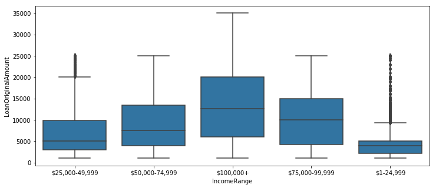

```python
plt.figure(figsize= [12, 5])
sb.boxplot(data= df_clean, x= 'IncomeRange', y= 'LoanOriginalAmount', color= base_color);
```

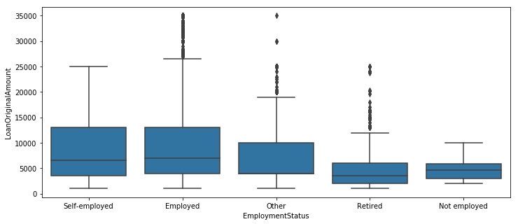

```python
plt.figure(figsize= [12, 5])
sb.boxplot(data= df_clean, x= 'EmploymentStatus', y= 'LoanOriginalAmount', color= base_color);
```

Q10. Do employment status and income range affect the amount of loan to borrow?

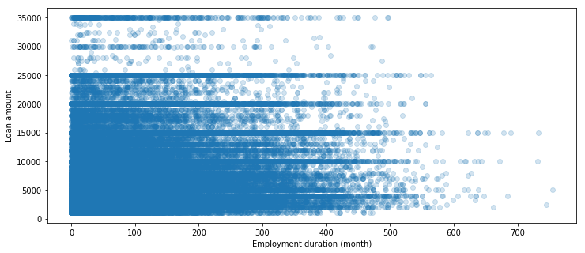

```python
plt.figure(figsize= [12, 5])
plt.scatter(data= df_clean, x= 'EmploymentStatusDuration', y= 'LoanOriginalAmount', alpha= 1/5);
plt.xlabel('Employment duration (month)');
plt.ylabel('Loan amount');
```

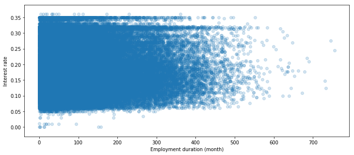

```python
plt.figure(figsize= [12, 5])
plt.scatter(data= df_clean, x= 'EmploymentStatusDuration', y= 'BorrowerRate', alpha= 1/5);
plt.xlabel('Employment duration (month)');
plt.ylabel('Interest rate');
```

Q11. How does employment duration affect the interest rate and loan amount?

Employment duration does not have a significant effect on the loan amount and the interest rate.

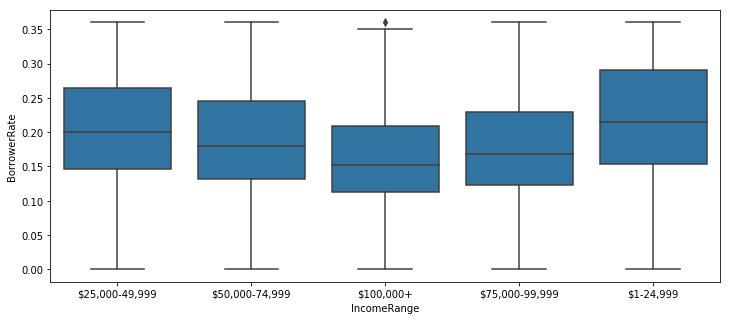

```python
plt.figure(figsize= [12, 5])
sb.boxplot(data= df_clean, x= 'IncomeRange', y= 'BorrowerRate', color= base_color);
```

Comment: I used a boxplot to show the relationship between a categorical vs. a numeric variables. Income range also affects the interest rate of the loan. The median interest rate decreases as the income range increases.

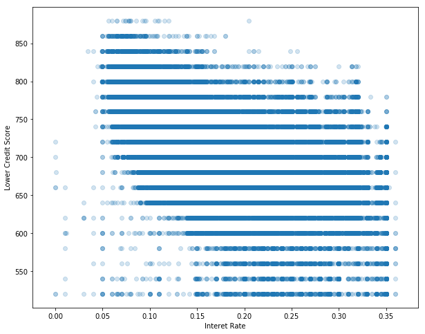

```python
plt.figure(figsize= [10, 8])
plt.scatter(data= df_clean, y= 'CreditScoreRangeLower', x= 'BorrowerRate', alpha= 1/5);
plt.xlabel('Interet Rate');
plt.ylabel('Lower Credit Score');
```

Q12. Does low credit score increase the interest rate of a loan?

As expected, credit score affects the rate of interest of the borrower's loan. As depicted in the scatter plot above, it is very unlikely to receive a loan with less than 15% interest rate if your lower credit score is less than 620. The majority of those applicants with the lower credit score of above 850 are entitled to low interest rate (5%-10%) loans.

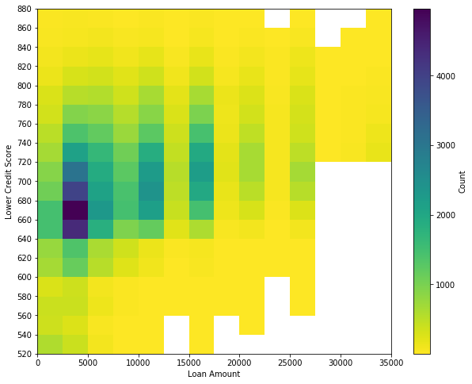

```python
plt.figure(figsize= [10, 8])
x_bins= np.arange(520, 880+ 20, 20)
y_bins= np.arange(0, 35000+ 2500, 2500)
plt.hist2d(data= df_clean, y= 'CreditScoreRangeLower', x= 'LoanOriginalAmount', cmin= 0.5, cmap= 'viridis_r', bins= [y_bins, x_bins]);
y_ticks= df_clean['CreditScoreRangeLower'].value_counts().index.sort_values()
plt.yticks(y_ticks, y_ticks)
plt.colorbar(label= 'Count');
plt.xlabel('Loan Amount');
plt.ylabel('Lower Credit Score');
```

Q12. What is the best way of showing the distribution of loans based on lower credit score and loan amount?

Heatmap can be used for showing the distribution lower credit score and loan amount that both are numeric variables. According to the above heatmap, more than 4000 applicants have a lower credit score of 660 to 680 and borrowed 2500 to 5000 dollars. The heatmap also shows that the minimum lower credit score required to get loans of more than \$27,500 is 720.

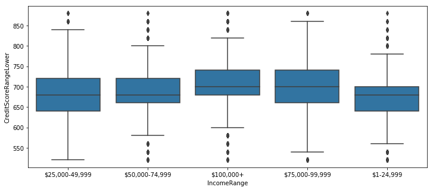

```python
plt.figure(figsize= [12, 5])
sb.boxplot(data= df_clean, x= 'IncomeRange', y= 'CreditScoreRangeLower', color= base_color);
```

Q13. Do applicants with higher salary have better credit scores?

It is interesting to know if people with higher salary also have better credit scores. The above boxplot confirms that applicant with more than \$100,000 income have the best minimun and median credit scores.

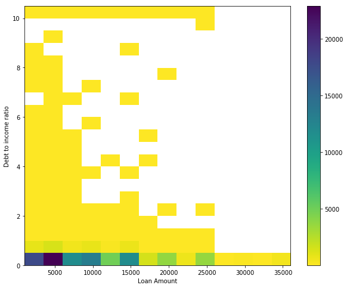

```python
plt.figure(figsize= [10, 8])
y_bins= np.arange(0, 10.01+ 0.5, 0.5)
x_bins= np.arange(1000, 35000+ 2500, 2500)
plt.hist2d(data= df_clean, x= 'LoanOriginalAmount', y= 'DebtToIncomeRatio', cmin= 0.5, cmap= 'viridis_r', bins= [x_bins, y_bins]);
plt.colorbar();
plt.xlabel('Loan Amount');
plt.ylabel('Debt to income ratio');
```

Q14. How does high debt-to-income ratio affect the loan amount?

It is clear from the above heatmap that debt-to-income ratio has tangible influence on the amount of loan to borrow. The figure shows that it is impossible to get more than \$27,500 loan if your debt-to-income ratio is above 50%.

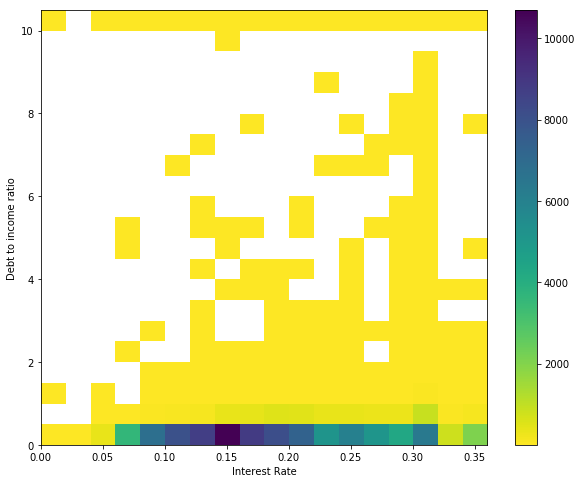

```python
plt.figure(figsize= [10, 8])
y_bins= np.arange(0, 10.01+ 0.5, 0.5)
x_bins= np.arange(0, 0.36+ 0.02, 0.02)
plt.hist2d(data= df_clean, x= 'BorrowerRate', y= 'DebtToIncomeRatio', cmin= 0.5, cmap= 'viridis_r', bins= [x_bins, y_bins]);
plt.colorbar();
plt.xlabel('Interest Rate');
plt.ylabel('Debt to income ratio');
```

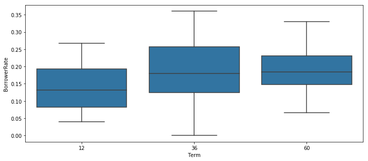

```python
plt.figure(figsize= [12, 5])
sb.boxplot(data= df_clean, x= 'Term', y= 'BorrowerRate', color= base_color);
```

Q15. Which loan term offers the lowest and highest interest rates?

As expected, the boxplot shows that the largest median interest rate belongs to loans with the duratio of 60 months followed by 36 and 12 months. The 36-month loan term includes both the lowest and highest interest rates.

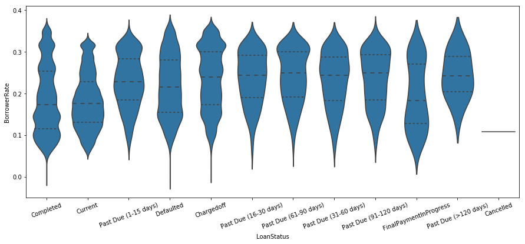

```python
plt.figure(figsize= [15, 6])
sb.violinplot(data= df_clean, x= 'LoanStatus', y= 'BorrowerRate', color= base_color, inner= 'quartile');
plt.xticks(rotation= 20);
```

Q16. What is an important characteristic of past due, charged off and defaulted loans?

As depicted in the violin plot, for defaulted, chargedoff and past due types of loan status, there is a high density of interest rates more than 20% and the median interest rate is also higher than 20% while this density is considerably smaller for completed and final payment ones.

### Did you observe any interesting relationships between the other features (not the main feature(s) of interest)?

Generally, applicants with higher salaries have better credit scores than low-income applicants.

## Multivariate Exploration

In this section plots of three variables are created to investigate the data even further.

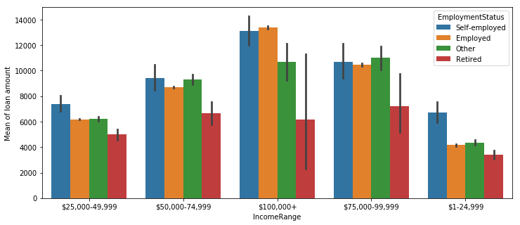

```python
df_mod= df_clean.query('EmploymentStatus != "Not employed" and IncomeRange != "Not employed"')
plt.figure(figsize= [12,5])
ax= sb.barplot(data= df_mod, x= 'IncomeRange', y= 'LoanOriginalAmount', hue= 'EmploymentStatus')
plt.ylabel('Mean of loan amount');
```

Q17. How do self-employed and employed applicant compare in terms of average amount of loan they can borrow based on their salaries?

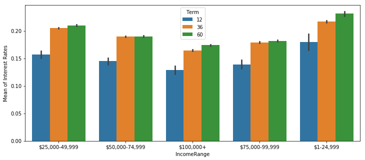

```python
df_mod= df_clean.query('EmploymentStatus != "Not employed" and IncomeRange != "Not employed"')
plt.figure(figsize= [12,5])
ax= sb.barplot(data= df_mod, x= 'IncomeRange', y= 'BorrowerRate', hue= 'Term')
plt.ylabel('Mean of Interest Rates');
```

Q18. How do income and loan duration affect interest rate on average?

As expected, the barchat shows that the largest average interest rates belong to loans with the duration of 60 months followed by 36 and 12 months. This is because longer term economic conditions are much harder to predict thus lenders charge higher interest rates for longer term loans. It can be observed that low-income people have to pay more interest on their loans as higher risk is associated with their payment compared to high-income applicants.

### Talk about some of the relationships you observed in this part of the investigation. Were there features that strengthened each other in terms of looking at your feature(s) of interest?

When both the employment status and income range are considered against the loan amount in the above multivariate visualization, it becomes more clear these two variables are the main driver for the amount of loan one can borrow. In addition to income range, loan term is a key feature determining the interest rate.

```python
df_clean.to_csv('clean_loan_data.csv', index= False)
```